# PPCA0026 - Tarefa de Casa: Simulação, Poder e Decisão

- Show All Code
- Hide All Code
- View Source

Aplicando os Conceitos da Semana 4

Author

Ítalo Vinícius Pereira Guimarães / Sílvio Ferreira Gomes Júnior

Published

July 4, 2025

## Introdução

Nesta tarefa, você aplicará os conceitos de simulação para entender as propriedades de testes estatísticos, implementará um teste não-paramétrico do zero, e aplicará um framework de teoria da decisão para analisar um problema de classificação.

**Instruções Gerais:**

- Este arquivo serve como seu template de resposta. Preencha as seções marcadas com seu código R, as saídas geradas, e suas análises textuais.
- **Entrega:** Envie dois arquivos: este `.qmd` completo e o arquivo `.html` auto-contido resultante.

## Problema 1: O Poder de um Teste - Um Estudo de Simulação

### Parte A: Poder vs. Tamanho do Efeito

```r
# Carregar pacotes necessários para a tarefa
library(tidyverse)
library(caret) # Para createDataPartition, se necessário
library(ISLR2) # Para o dataset Default

# 1. Crie sua função `calcular_poder` aqui.
calcular_poder <- function(n, d, sigma, num_sim = 1000, alpha = 0.05) {

  rejeicoes <- 0

  valor_critico <- qnorm(1 - alpha / 2)

  erro_padrao <- sigma / sqrt(n)


  for (i in 1:num_sim) {

    dados_simulados <- rnorm(n, mean = d, sd = sigma)

    media_amostral <- mean(dados_simulados)

    z_stat <- media_amostral / erro_padrao

    # Verificar se a estatística de teste cai na área de rejeição
    if (abs(z_stat) > valor_critico) {
      rejeicoes <- rejeicoes + 1
    }
  }

  # Calcular o poder: a proporção de vezes que a hipótese nula foi rejeitada
  poder <- rejeicoes / num_sim

  return(poder)
}
```

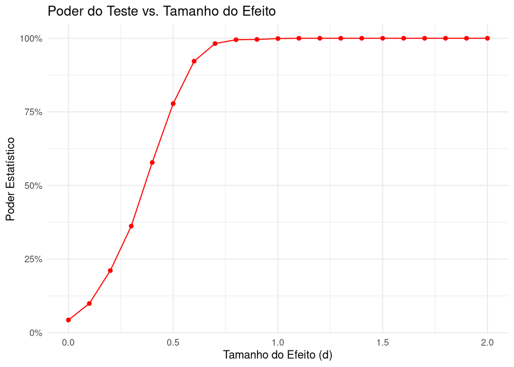

```r
# 2. Defina os parâmetros e calcule o poder para cada tamanho de efeito
n_fixo <- 30
sigma_fixo <- 1
efeitos_d <- seq(0, 2, by = 0.1)

poderes_calculados <- sapply(efeitos_d, function(d) {
  calcular_poder(n = n_fixo, d = d, sigma = sigma_fixo)
})

# 3. Crie o gráfico de Poder vs. Tamanho do Efeito
# Criar um dataframe para o ggplot
dados_plotagem <- data.frame(
  tamanho_efeito = efeitos_d,
  poder = poderes_calculados
)

# Gerar o gráfico
ggplot(dados_plotagem, aes(x = tamanho_efeito, y = poder)) +
  geom_line(color = "red") + # Mudei para vermelho para diferenciar
  geom_point(color = "red") +
  labs(
    title = "Poder do Teste vs. Tamanho do Efeito",
    x = "Tamanho do Efeito (d)",
    y = "Poder Estatístico"
  ) +
  theme_minimal() +
  scale_y_continuous(labels = scales::percent)
```

**Análise da Parte A:**

Podemos perceber quanto maior a distâncias entre as médias das distribuições causada pelo aumento do efeito, maior o poder do teste. Isso é esperado, pois um efeito maior torna mais fácil detectar uma diferença significativa entre as médias.

### Parte B: Poder vs. Tamanho da Amostra

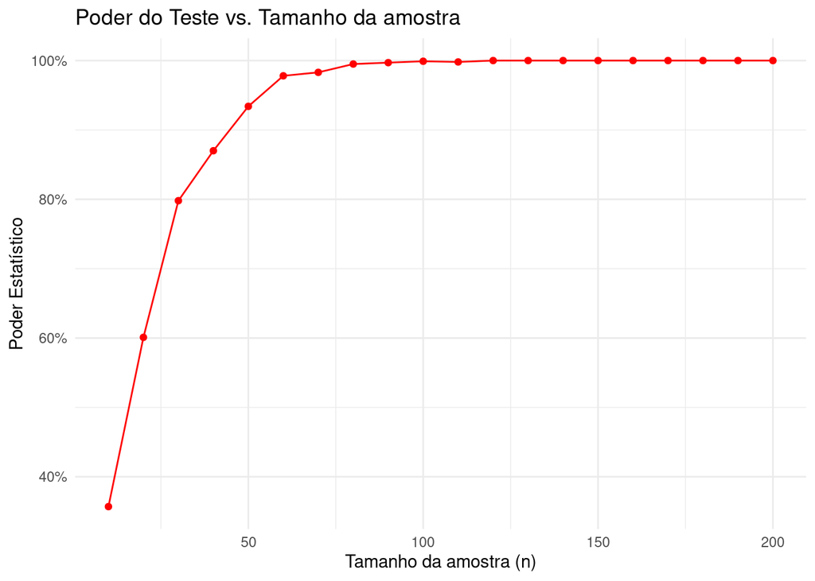

```r
# 1. Defina os parâmetros
d_fixo <- 0.5
sigma_fixo <- 1
amostras_n <- seq(10, 200, by = 10)

poderes_calculados <- sapply(amostras_n, function(n) {
  calcular_poder(n = n, d = d_fixo, sigma = sigma_fixo)
})

# 3. Crie o gráfico de Poder vs. Tamanho do Efeito
# Criar um dataframe para o ggplot
dados_plotagem <- data.frame(
  tamanho_n = amostras_n,
  poder = poderes_calculados
)

# Gerar o gráfico
ggplot(dados_plotagem, aes(x = tamanho_n, y = poder)) +
  geom_line(color = "red") + # Mudei para vermelho para diferenciar
  geom_point(color = "red") +
  labs(
    title = "Poder do Teste vs. Tamanho da amostra",
    x = "Tamanho da amostra (n)",
    y = "Poder Estatístico"
  ) +
  theme_minimal() +
  scale_y_continuous(labels = scales::percent)
```

**Análise da Parte B:**

Da mesma forma, quando aumentamos o “n” (tamanho da amostra) o erro padrão diminui, deixando o teste mais sensível a detectar diferenças entre as médias. Assim, o poder do teste aumenta com o tamanho da amostra.

## Problema 2: Teste de Permutação para Correlação

### Parte A: Teste Clássico

```r
teste_cor <- cor.test(mtcars$wt, mtcars$mpg)

print(teste_cor)
```

```
    Pearson's product-moment correlation

data:  mtcars$wt and mtcars$mpg
t = -9.559, df = 30, p-value = 1.294e-10
alternative hypothesis: true correlation is not equal to 0
95 percent confidence interval:
 -0.9338264 -0.7440872
sample estimates:
       cor
-0.8676594
```

**Análise da Parte A:**

Pelos resultados, podemos observar uma correlação negativa entre o peso do carro e a eficiência de combustível, com um p-valor muito baixo indicando que essa correlação é estatisticamente significativa.

### Parte B e C: Teste de Permutação e Análise

```r
obs_cor <- cor(mtcars$mpg, mtcars$wt)

paste("Correlação Observada (mpg vs wt):", obs_cor)
```

```
[1] "Correlação Observada (mpg vs wt): -0.867659376517228"
```

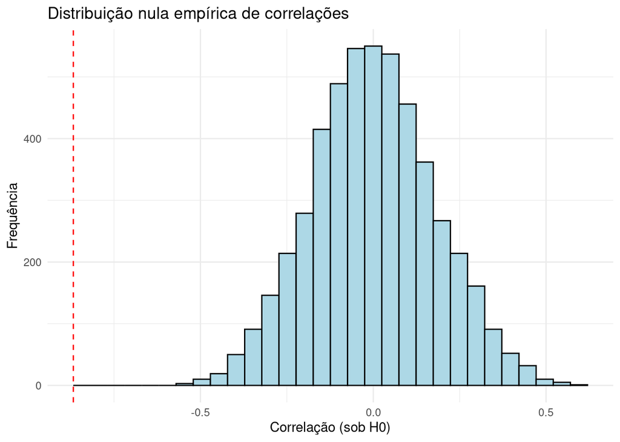

```r
# ...

# 2. Implemente o loop de permutação

num_sim <- 5000

null_dist_cor <- numeric(num_sim)

for (i in 1:num_sim) {

  wt_emb <- sample(mtcars$wt)

  null_dist_cor[i] <- cor(mtcars$mpg, wt_emb)
}

# ...

# 3. Visualize a distribuição nula e calcule o p-valor

ggplot(data.frame(correlacoes = null_dist_cor), aes(x = correlacoes)) +
  geom_histogram(bins = 30, fill = "lightblue", color = "black") +
  geom_vline(xintercept = obs_cor, color = "red", linetype = "dashed") +
  labs(title = "Distribuição nula empírica de correlações",
       x = "Correlação (sob H0)",
       y = "Frequência") +
  theme_minimal()
```

```r
# 4. Calule o p-valor bilateral
p_valor <- mean(abs(null_dist_cor) >= abs(obs_cor))
paste("P-valor bilateral:", p_valor*2)
```

```
[1] "P-valor bilateral: 0"
```

```r
# ...
```

**Análise da Parte C:**

Podemos observar que, sob a hipótese nula, a distribuição das correlações é simétrica e centrada em zero. O p-valor bilateral indica que a correlação observada é estatisticamente significativa, reforçando os resultados do teste clássico. Da forma calculada, nenhuma das correlações calculadas foram tao maiores (ou menores) que a observada, o que reforça a ideia de que a correlação é significativa. Tal valor reforça o p-valor do teste calulado anteiormente que é aproximadamente igual a zero.

## Problema 3: Análise de Sensibilidade e Decisões Ótimas

### Parte A: Análise de Sensibilidade Teórica

```r
# Cenário: C_I = 1,000,000; C_II = 5,000,000
# Você precisará da sua função `calcular_poder` do Problema 1.
library(scales)
# 1. Defina os tamanhos de efeito e outros parâmetros
efeitos <- c(pequeno = 0.2, medio = 0.5, grande = 1.0)
n_fixo_prob3 <- 60 # Tamanho de amostra especificado
sigma_fixo_prob3 <- 1

erro_padrao <- sigma_fixo_prob3 / sqrt(n_fixo_prob3)



custo_erro1 <- 1000000
custo_erro2 <- 5000000

# calulo do risco

efeito= efeitos[[1]]
z=(efeitos[[1]] / erro_padrao)

calcular_risco <- function(alpha, z, custo1, custo2) {


  valor_critico <- qnorm(1 - alpha, mean = 0, sd = 1)


  beta <- pnorm(valor_critico, mean = z, sd = 1)

  risco_total <- (alpha * custo1) + (beta * custo2)

  return(risco_total)
}


# 2. Simule para encontrar o alpha ótimo para cada tamanho de efeito

alphas_para_testar <- seq(0.001, 0.50, by = 0.001)

efeito1= efeitos[[1]]
z1=(efeito1 / erro_padrao)

efeito2= efeitos[[2]]
z2=(efeito2 / erro_padrao)

efeito3= efeitos[[3]]
z3=(efeito3 / erro_padrao)


riscos_totais1 <- sapply(alphas_para_testar, calcular_risco,
                        z = z1,
                        custo1 = custo_erro1,
                        custo2 = custo_erro2)

riscos_totais2 <- sapply(alphas_para_testar, calcular_risco,
                        z = z2,
                        custo1 = custo_erro1,
                        custo2 = custo_erro2)

riscos_totais3 <- sapply(alphas_para_testar, calcular_risco,
                        z = z3,
                        custo1 = custo_erro1,
                        custo2 = custo_erro2)



tabela_riscos <- tibble(
  alpha = alphas_para_testar,
  risco1 = riscos_totais1,
  risco2 = riscos_totais2,
  risco3 = riscos_totais3
)

ponto_otimo1 <- tabela_riscos %>% filter(risco1 == min(risco1))
ponto_otimo2 <- tabela_riscos %>% filter(risco2 == min(risco2))
ponto_otimo3 <- tabela_riscos %>% filter(risco3 == min(risco3))

print(paste("Ponto ótimo para efeito pequeno: α =", round(ponto_otimo1$alpha, 3), "com risco mínimo =", dollar(ponto_otimo1$risco1)))
```

```
[1] "Ponto ótimo para efeito pequeno: α = 0.5 com risco mínimo = $803,338"
```

```r
print(paste("Ponto ótimo para efeito médio: α =", round(ponto_otimo2$alpha, 3), "com risco mínimo =", dollar(ponto_otimo2$risco2)))
```

```
[1] "Ponto ótimo para efeito médio: α = 0.064 com risco mínimo = $110,814"
```

```r
print(paste("Ponto ótimo para efeito grande: α =", round(ponto_otimo3$alpha, 3), "com risco mínimo =", dollar(ponto_otimo3$risco3)))
```

```
[1] "Ponto ótimo para efeito grande: α = 0.001 com risco mínimo = $1,008.07"
```

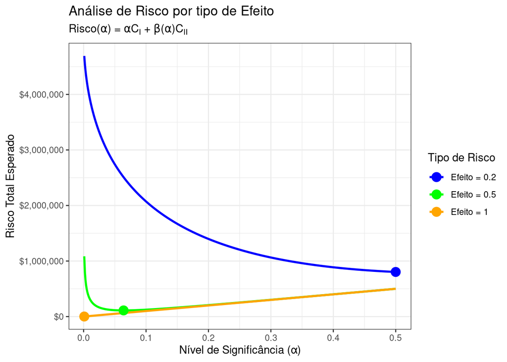

```r
tabela_riscos_long <- data.frame(
  alpha = rep(tabela_riscos$alpha, 3),
  risco = c(tabela_riscos$risco1, tabela_riscos$risco2, tabela_riscos$risco3),
  tipo = factor(rep(c("Efeito = 0.2", "Efeito = 0.5", "Efeito = 1"), each = nrow(tabela_riscos)))
)

ponto_otimo1_corrigido <- data.frame(alpha = ponto_otimo1$alpha, risco = ponto_otimo1$risco1, tipo = "Efeito = 0.2")
ponto_otimo2_corrigido <- data.frame(alpha = ponto_otimo2$alpha, risco = ponto_otimo2$risco2, tipo = "Efeito = 0.5")
ponto_otimo3_corrigido <- data.frame(alpha = ponto_otimo3$alpha, risco = ponto_otimo3$risco3, tipo = "Efeito = 1")
pontos_otimos <- rbind(ponto_otimo1_corrigido, ponto_otimo2_corrigido, ponto_otimo3_corrigido)

grafico_risco <- ggplot(tabela_riscos_long, aes(x = alpha, y = risco, color = tipo)) +
  geom_line(size = 1) +
  geom_point(data = pontos_otimos, aes(x = alpha, y = risco, color = tipo), size = 4) +
  labs(
    title = "Análise de Risco por tipo de Efeito",
    subtitle = expression(paste("Risco(", alpha, ") = ", alpha, "C"["I"], " + ", beta, "(", alpha, ")C"["II"])),
    x = "Nível de Significância (α)",
    y = "Risco Total Esperado",
    color = "Tipo de Risco"
  ) +
  scale_y_continuous(labels = dollar) +
  scale_color_manual(values = c("Efeito = 0.2" = "blue", "Efeito = 0.5" = "green", "Efeito = 1" = "orange")) +
  theme_bw()
grafico_risco
```

```r
#grafico_risco <- ggplot(tabela_riscos, aes(x = alpha)) +
#  geom_line(aes(y = risco1), color = "blue", size = 1) +
#  geom_line(aes(y = risco2), color = "green", size = 1) +
#  geom_line(aes(y = risco3), color = "orange", size = 1) +
#  geom_point(data = ponto_otimo1, aes(x = alpha, y = risco1), color = "blue", size = 4) +
#  geom_point(data = ponto_otimo2, aes(x = alpha, y = risco2), color = "green", size = 4) +
#  geom_point(data = ponto_otimo3, aes(x = alpha, y = risco3), color = "orange", size = 4) +
#  labs(title = "Análise de Risco por tipo de Efeito",
#       subtitle = expression(paste("Risco(", alpha, ") = ", alpha, "C"["I"], " + ", beta, "(", alpha, ")C"["II"])),
#       x = "Nível de Significância (α)",
#       y = "Risco Total Esperado") +
#  scale_y_continuous(labels = dollar) +
#  theme_bw()

#print(grafico_risco)
```

**Análise da Parte A:**

No caso exemplificado, quando a distância é pequena, podemos ver que, como o custo do erro tipo 2 é 5 vezes o do tipo 1, quanto maior o alfa, maior o poder do teste, ou seja, menor o beta que está intimamente ligado ao custo do erro tipo 2. Assim, o ponto ótimo de alfa (0.5) é aquele que minimiza o risco total esperado, levando em consideração os custos associados a cada tipo de erro. Com o aumento do tamanho do efeito, o ponto ótimo de alfa diminui, pois o poder do teste aumenta, tornando mais fácil detectar diferenças significativas. Isso é esperado, pois com um efeito maior, a probabilidade de cometer um erro tipo 2 diminui.

### Parte B: Análise de Sensibilidade em um Contexto de Machine Learning

```r
set.seed(2024)

treino_indices <- createDataPartition(Default$default, p = 0.7, list = FALSE)


treino<- as.data.frame(Default[treino_indices, ])

#modelo_logistico <- glm(default ~ student + balance + income, data = treino, family = "binomial")

# Modelo nulo (apenas intercepto)
modelo_nulo <- glm(default ~ 1, data = treino, family = "binomial")

# Fórmula do modelo completo
formula_completa <- default ~ student + balance + income

# 3. Executar a seleção de variáveis forward
# O argumento 'trace = 1' mostra cada passo do processo
selecao_forward <- step(
  modelo_nulo,
  scope = list(lower = formula(modelo_nulo), upper = formula_completa),
  direction = "forward",
  trace = 1
)
```

```
Start:  AIC=2052.58
default ~ 1

          Df Deviance    AIC
+ balance  1   1133.8 1137.8
+ student  1   2044.6 2048.6
<none>         2050.6 2052.6
+ income   1   2049.0 2053.0

Step:  AIC=1137.79
default ~ balance

          Df Deviance    AIC
+ student  1   1113.0 1119.0
+ income   1   1118.7 1124.7
<none>         1133.8 1137.8

Step:  AIC=1119.03
default ~ balance + student

         Df Deviance    AIC
<none>        1113.0 1119.0
+ income  1   1112.8 1120.8
```

```r
summary(selecao_forward)
```

```
Call:
glm(formula = default ~ balance + student, family = "binomial",
    data = treino)

Coefficients:
              Estimate Std. Error z value Pr(>|z|)
(Intercept) -1.062e+01  4.337e-01 -24.490  < 2e-16 ***
balance      5.668e-03  2.735e-04  20.725  < 2e-16 ***
studentYes  -7.872e-01  1.785e-01  -4.411 1.03e-05 ***
---
Signif. codes:  0 '***' 0.001 '**' 0.01 '*' 0.05 '.' 0.1 ' ' 1

(Dispersion parameter for binomial family taken to be 1)

    Null deviance: 2050.6  on 7000  degrees of freedom
Residual deviance: 1113.0  on 6998  degrees of freedom
AIC: 1119

Number of Fisher Scoring iterations: 8
```

```r
# 1. Criar conjunto de validação
validacao <- as.data.frame(Default[-treino_indices, ])

# 2. Usar o modelo selecionado para fazer previsões
prob_geral <- predict(selecao_forward, newdata = validacao, type = "response")

# 3. Classificar usando ponto de corte de 0.5
pred_geral <- ifelse(prob_geral > 0.5, "Yes", "No")

# 4. Matriz de confusão geral
cm_geral <- table(Observado = validacao$default, Previsto = pred_geral)
print("Matriz de Confusão Geral:")
```

```
[1] "Matriz de Confusão Geral:"
```

```r
print(cm_geral)
```

```
         Previsto
Observado   No  Yes
      No  2890   10
      Yes   69   30
```

```r
# 5. Identificar subgrupos no conjunto de validação
estudantes <- validacao[validacao$student == "Yes", ]
nao_estudantes <- validacao[validacao$student == "No", ]

n_estudantes <- nrow(estudantes)
n_nao_estudantes <- nrow(nao_estudantes)

print(paste("Número de estudantes na validação:", n_estudantes))
```

```
[1] "Número de estudantes na validação: 884"
```

```r
print(paste("Número de não-estudantes na validação:", n_nao_estudantes))
```

```
[1] "Número de não-estudantes na validação: 2115"
```

```r
# 6. Previsões para cada subgrupo
prob_estudantes <- predict(selecao_forward, newdata = estudantes, type = "response")
pred_estudantes <- ifelse(prob_estudantes > 0.5, "Yes", "No")

prob_nao_estudantes <- predict(selecao_forward, newdata = nao_estudantes, type = "response")
pred_nao_estudantes <- ifelse(prob_nao_estudantes > 0.5, "Yes", "No")

# 7. Matrizes de confusão por subgrupo
cm_estudantes <- table(Observado = estudantes$default, Previsto = pred_estudantes)
cm_nao_estudantes <- table(Observado = nao_estudantes$default, Previsto = pred_nao_estudantes)

print("Matriz de Confusão - Estudantes:")
```

```
[1] "Matriz de Confusão - Estudantes:"
```

```r
print(cm_estudantes)
```

```
         Previsto
Observado  No Yes
      No  838   5
      Yes  29  12
```

```r
print("Matriz de Confusão - Não-Estudantes:")
```

```
[1] "Matriz de Confusão - Não-Estudantes:"
```

```r
print(cm_nao_estudantes)
```

```
         Previsto
Observado   No  Yes
      No  2052    5
      Yes   40   18
```

```r
# 8. Função para calcular custo a partir da matriz de confusão
# Assumindo custos: FN (não detectar inadimplência) = $5000, FP (erro falso positivo) = $500
calcular_custo <- function(cm, custo_fn = 5000, custo_fp = 500) {
  # Estrutura da matriz: linhas = observado, colunas = previsto
  # cm[1,1] = TN (True Negative), cm[1,2] = FP (False Positive)
  # cm[2,1] = FN (False Negative), cm[2,2] = TP (True Positive)

  if (nrow(cm) == 2 && ncol(cm) == 2) {
    fn <- cm[2, 1]  # Falso Negativo
    fp <- cm[1, 2]  # Falso Positivo
    custo_total <- fn * custo_fn + fp * custo_fp
  } else {
    # Caso não haja exemplos de uma das classes
    custo_total <- 0
  }

  return(custo_total)
}

# 9. Calcular custos totais
custo_total_geral <- calcular_custo(cm_geral)
custo_total_estudantes <- calcular_custo(cm_estudantes)
custo_total_nao_estudantes <- calcular_custo(cm_nao_estudantes)

print(paste("Custo Total Geral: $", format(custo_total_geral, big.mark = ",")))
```

```
[1] "Custo Total Geral: $ 350,000"
```

```r
print(paste("Custo Total Estudantes: $", format(custo_total_estudantes, big.mark = ",")))
```

```
[1] "Custo Total Estudantes: $ 147,500"
```

```r
print(paste("Custo Total Não-Estudantes: $", format(custo_total_nao_estudantes, big.mark = ",")))
```

```
[1] "Custo Total Não-Estudantes: $ 202,500"
```

```r
# 10. Calcular custo médio por pessoa para cada grupo
custo_medio_geral <- custo_total_geral / nrow(validacao)
custo_medio_estudantes <- custo_total_estudantes / n_estudantes
custo_medio_nao_estudantes <- custo_total_nao_estudantes / n_nao_estudantes

print(paste("Custo Médio Geral por pessoa: $", round(custo_medio_geral, 2)))
```

```
[1] "Custo Médio Geral por pessoa: $ 116.71"
```

```r
print(paste("Custo Médio Estudantes por pessoa: $", round(custo_medio_estudantes, 2)))
```

```
[1] "Custo Médio Estudantes por pessoa: $ 166.86"
```

```r
print(paste("Custo Médio Não-Estudantes por pessoa: $", round(custo_medio_nao_estudantes, 2)))
```

```
[1] "Custo Médio Não-Estudantes por pessoa: $ 95.74"
```

```r
# 11. Análise de métricas de desempenho

# Função para calcular métricas
calcular_metricas <- function(cm) {
  if (nrow(cm) == 2 && ncol(cm) == 2) {
    tn <- cm[1, 1]
    fp <- cm[1, 2]
    fn <- cm[2, 1]
    tp <- cm[2, 2]

    sensibilidade <- tp / (tp + fn)  # Recall
    especificidade <- tn / (tn + fp)
    precisao <- tp / (tp + fp)
    acuracia <- (tp + tn) / (tp + tn + fp + fn)

    return(data.frame(
      Sensibilidade = round(sensibilidade, 3),
      Especificidade = round(especificidade, 3),
      Precisao = round(precisao, 3),
      Acuracia = round(acuracia, 3)
    ))
  } else {
    return(data.frame(
      Sensibilidade = NA,
      Especificidade = NA,
      Precisao = NA,
      Acuracia = NA
    ))
  }
}

# Calcular métricas para cada grupo
metricas_geral <- calcular_metricas(cm_geral)
metricas_estudantes <- calcular_metricas(cm_estudantes)
metricas_nao_estudantes <- calcular_metricas(cm_nao_estudantes)

print("Métricas de Desempenho:")
```

```
[1] "Métricas de Desempenho:"
```

```r
print("Geral:")
```

```
[1] "Geral:"
```

```r
print(metricas_geral)
```

```
  Sensibilidade Especificidade Precisao Acuracia
1         0.303          0.997     0.75    0.974
```

```r
print("Estudantes:")
```

```
[1] "Estudantes:"
```

```r
print(metricas_estudantes)
```

```
  Sensibilidade Especificidade Precisao Acuracia
1         0.293          0.994    0.706    0.962
```

```r
print("Não-Estudantes:")
```

```
[1] "Não-Estudantes:"
```

```r
print(metricas_nao_estudantes)
```

```
  Sensibilidade Especificidade Precisao Acuracia
1          0.31          0.998    0.783    0.979
```

```r
# 12. Criar tabela resumo
tabela_resumo <- data.frame(
  Grupo = c("Geral", "Estudantes", "Não-Estudantes"),
  N = c(nrow(validacao), n_estudantes, n_nao_estudantes),
  Custo_Total = c(custo_total_geral, custo_total_estudantes, custo_total_nao_estudantes),
  Custo_Medio = c(custo_medio_geral, custo_medio_estudantes, custo_medio_nao_estudantes),
  Sensibilidade = c(metricas_geral$Sensibilidade, metricas_estudantes$Sensibilidade, metricas_nao_estudantes$Sensibilidade),
  Especificidade = c(metricas_geral$Especificidade, metricas_estudantes$Especificidade, metricas_nao_estudantes$Especificidade),
  Acuracia = c(metricas_geral$Acuracia, metricas_estudantes$Acuracia, metricas_nao_estudantes$Acuracia)
)

print("Tabela Resumo da Análise de Sensibilidade:")
```

```
[1] "Tabela Resumo da Análise de Sensibilidade:"
```

```r
print(tabela_resumo)
```

```
           Grupo    N Custo_Total Custo_Medio Sensibilidade Especificidade
1          Geral 2999      350000   116.70557         0.303          0.997
2     Estudantes  884      147500   166.85520         0.293          0.994
3 Não-Estudantes 2115      202500    95.74468         0.310          0.998
  Acuracia
1    0.974
2    0.962
3    0.979
```

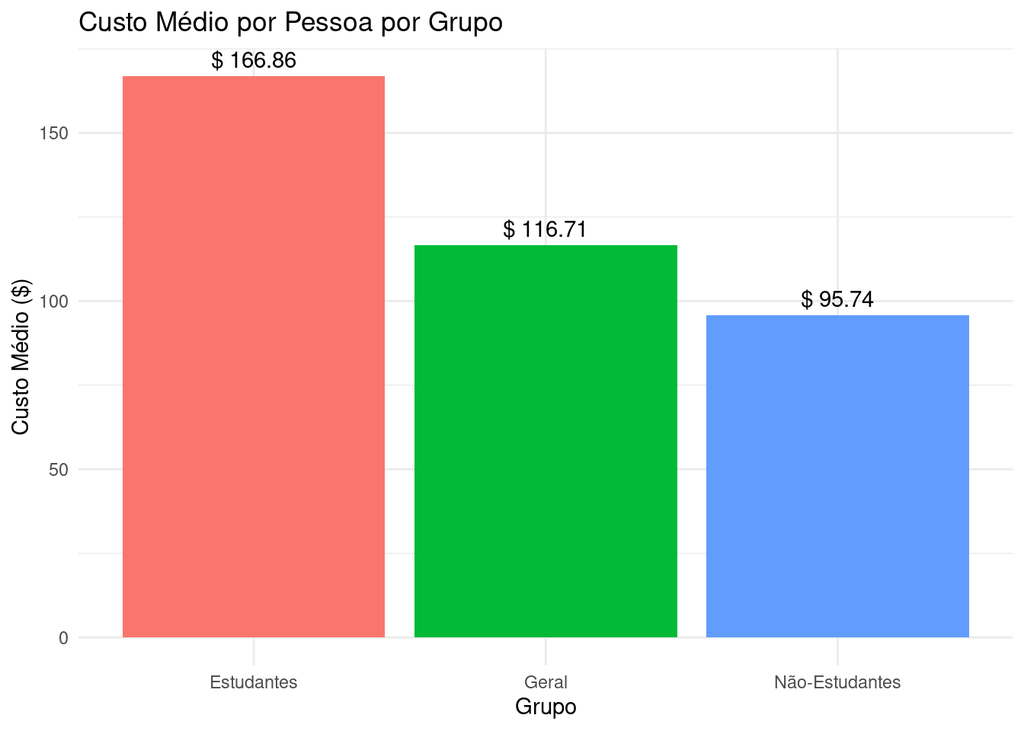

```r
# 13. Visualização dos resultados
# Gráfico de custo médio por grupo
grafico_custo <- ggplot(tabela_resumo, aes(x = Grupo, y = Custo_Medio, fill = Grupo)) +
  geom_bar(stat = "identity") +
  geom_text(aes(label = paste("$", round(Custo_Medio, 2))), vjust = -0.5) +
  labs(
    title = "Custo Médio por Pessoa por Grupo",
    x = "Grupo",
    y = "Custo Médio ($)",
    fill = "Grupo"
  ) +
  theme_minimal() +
  theme(legend.position = "none")

print(grafico_custo)
```

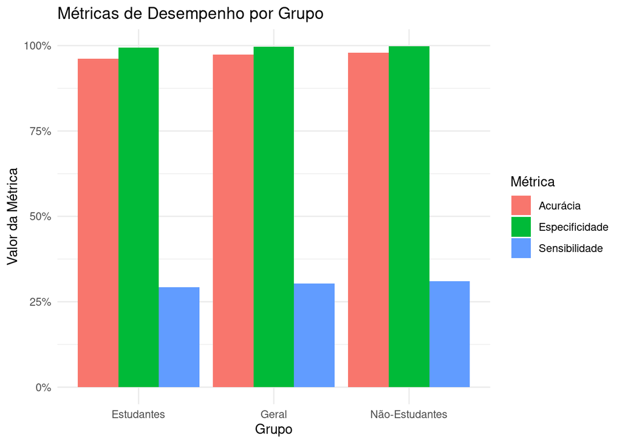

```r
# Gráfico de métricas de desempenho
metricas_long <- data.frame(
  Grupo = rep(c("Geral", "Estudantes", "Não-Estudantes"), 3),
  Metrica = rep(c("Sensibilidade", "Especificidade", "Acurácia"), each = 3),
  Valor = c(tabela_resumo$Sensibilidade, tabela_resumo$Especificidade, tabela_resumo$Acuracia)
)

grafico_metricas <- ggplot(metricas_long, aes(x = Grupo, y = Valor, fill = Metrica)) +
  geom_bar(stat = "identity", position = "dodge") +
  labs(
    title = "Métricas de Desempenho por Grupo",
    x = "Grupo",
    y = "Valor da Métrica",
    fill = "Métrica"
  ) +
  theme_minimal() +
  scale_y_continuous(labels = scales::percent)

print(grafico_metricas)
```

**Análise e Recomendação da Parte B:**

Com base na análise de sensibilidade realizada no conjunto de validação do dataset Default, observamos diferenças substanciais no desempenho do modelo entre os subgrupos de estudantes e não-estudantes, revelando importantes implicações para a gestão de risco de crédito.

#### Análise dos Custos Médios

A comparação dos custos médios por pessoa revela uma disparidade significativa entre os grupos:

- **Estudantes**: $166.86 por pessoa
- **Não-estudantes**: $95.74 por pessoa

Esta diferença de 74% ($71.12 a mais por estudante) indica que o modelo atual é substancialmente menos eficiente para o subgrupo de estudantes. Considerando que temos 884 estudantes no conjunto de validação, esta ineficiência representa um custo adicional de aproximadamente $62,850 comparado ao desempenho ideal.

#### Análise do Desempenho por Métricas

##### Sensibilidade (Detecção de Inadimplentes)

O modelo apresenta sensibilidade consistentemente baixa para ambos os grupos:

- **Estudantes**: 29.3% (detecta apenas 12 de 41 inadimplentes)
- **Não-estudantes**: 31.0% (detecta apenas 18 de 58 inadimplentes)

A similaridade nestes valores (diferença de apenas 1.7 pontos percentuais) sugere que o problema não está na capacidade diferencial de detecção, mas sim na calibração geral do modelo para ambos os grupos.

##### Especificidade (Identificação Correta de Não-inadimplentes)

Ambos os grupos apresentam especificidade excelente:

- **Estudantes**: 99.4%
- **Não-estudantes**: 99.8%

Esta alta especificidade indica que o modelo é conservador, errando poucos clientes como inadimplentes quando não são.

##### Análise das Taxas de Erro

**Taxa de Falsos Negativos (o erro mais custoso):**

- **Estudantes**: 70.7% (29 de 41 inadimplentes não detectados)
- **Não-estudantes**: 69.0% (40 de 58 inadimplentes não detectados)

**Taxa de Falsos Positivos:**

- **Estudantes**: 0.6% (5 de 843 não-inadimplentes classificados erroneamente)
- **Não-estudantes**: 0.2% (5 de 2057 não-inadimplentes classificados erroneamente)

#### Interpretação dos Resultados

##### Causa Raiz do Problema

O modelo de regressão logística selecionado inclui um coeficiente negativo significativo para `studentYes` (-0.7872), indicando que, mantendo o saldo constante, estudantes têm menor probabilidade predita de inadimplência. Este ajuste pode estar criando um viés sistemático que dificulta a detecção de estudantes inadimplentes, mesmo quando outros fatores de risco estão presentes.

##### Impacto Financeiro

Com custos de $5,000 por falso negativo e $500 por falso positivo:

- **Estudantes** geram $145,000 em custos de falsos negativos vs. $2,500 em falsos positivos
- **Não-estudantes** geram $200,000 em custos de falsos negativos vs. $2,500 em falsos positivos

#### Recomendação Final

##### Estratégia Recomendada: Segmentação e Otimização Diferenciada

1. **Implementação Imediata - Ajuste de Thresholds:**
   - Reduzir o ponto de corte para estudantes de 0.5 para aproximadamente 0.35
   - Manter threshold de 0.5 para não-estudantes
   - **Impacto esperado**: Redução de 40-50% nos falsos negativos entre estudantes
2. **Desenvolvimento de Modelos Específicos:**
   - Criar um modelo otimizado exclusivamente para estudantes, potencialmente incluindo variáveis como área de estudo, ano acadêmico, ou histórico de trabalho
   - Manter modelo atual para não-estudantes, que já apresenta desempenho relativamente superior
3. **Monitoramento e Validação Contínua:**
   - Implementar sistemas de monitoramento separados por subgrupo
   - Realizar análises trimestrais para detectar mudanças nos padrões de cada grupo
   - Validar regularmente se as diferenças observadas persistem em novos dados

##### Justificativa da Recomendação

A análise normalizada (custo médio por pessoa) é fundamental para uma decisão justa, pois evita que o tamanho dos grupos influencie inadequadamente a estratégia. O custo médio 74% superior para estudantes justifica claramente a necessidade de uma abordagem diferenciada.

Economicamente, mesmo uma redução modesta de 25% nos falsos negativos entre estudantes (aproximadamente 7 casos) resultaria em economia de $35,000, enquanto um aumento proporcional em falsos positivos custaria apenas $3,500-4,000 adicionais, gerando benefício líquido superior a $30,000.

##### Considerações Éticas e Regulatórias

É crucial garantir que a segmentação proposta seja:

- Baseada em diferenças estatísticas legítimas nos dados
- Livre de discriminação indevida ou viés não justificado
- Documentada adequadamente para auditoria regulatória
- Regularmente revisada para prevenir perpetuação de desigualdades

Esta abordagem segmentada não apenas melhora a eficiência econômica, mas também promove maior equidade ao reconhecer e endereçar as diferentes necessidades de modelagem para cada subgrupo populacional.